# Moneyball Capstone Project

Alex Gifford

February 19, 2019

## Background

The Oakland A’s lost three key players (the lost boys) during the 2001 season. The team’s general manager responded by signing on a few players that were a bit under-the-radar. With these new players the team won 20 consecutive games in the 2002 season. This event was made into a book and a movie, both named “Moneyball”.  
The book argues that the Oakland A’s used a more statistical approach for choosing their new players. They found that on-base percentages and slugging percentage are better indicators of offensive success, and were cheaper on the market than many other qualities.

This is the capstone project Jose Portilla’s course “Data Science and Machine Learning Bootcamp with R”.

### Goal

We are going to use R to analyze data from [Sean Lahaman’s Website](http://www.seanlahman.com/baseball-archive/statistics/) and find undervalued players to replace the lost boys.

### Here is the data.

| yearID | teamID | lgID | playerID | salary |
| --- | --- | --- | --- | --- |
| 1985 | BAL | AL | murraed02 | 1472819 |
| 1985 | BAL | AL | lynnfr01 | 1090000 |
| 1985 | BAL | AL | ripkeca01 | 800000 |
| 1985 | BAL | AL | lacyle01 | 725000 |
| 1985 | BAL | AL | flanami01 | 641667 |
| 1985 | BAL | AL | boddimi01 | 625000 |

**Second**, we have the players statistics data

| playerID | yearID | stint | teamID | lgID | G | G_batting | AB | R | H | X2B | X3B | HR | RBI | SB | CS | BB | SO | IBB | HBP | SH | SF | GIDP | G_old |
| --- | --- | --- | --- | --- | --- | --- | --- | --- | --- | --- | --- | --- | --- | --- | --- | --- | --- | --- | --- | --- | --- | --- | --- |
| aardsda01 | 2004 | 1 | SFN | NL | 11 | 11 | 0 | 0 | 0 | 0 | 0 | 0 | 0 | 0 | 0 | 0 | 0 | 0 | 0 | 0 | 0 | 0 | 11 |
| aardsda01 | 2006 | 1 | CHN | NL | 45 | 43 | 2 | 0 | 0 | 0 | 0 | 0 | 0 | 0 | 0 | 0 | 0 | 0 | 0 | 1 | 0 | 0 | 45 |
| aardsda01 | 2007 | 1 | CHA | AL | 25 | 2 | 0 | 0 | 0 | 0 | 0 | 0 | 0 | 0 | 0 | 0 | 0 | 0 | 0 | 0 | 0 | 0 | 2 |
| aardsda01 | 2008 | 1 | BOS | AL | 47 | 5 | 1 | 0 | 0 | 0 | 0 | 0 | 0 | 0 | 0 | 0 | 1 | 0 | 0 | 0 | 0 | 0 | 5 |
| aardsda01 | 2009 | 1 | SEA | AL | 73 | 3 | 0 | 0 | 0 | 0 | 0 | 0 | 0 | 0 | 0 | 0 | 0 | 0 | 0 | 0 | 0 | 0 | NA |
| aardsda01 | 2010 | 1 | SEA | AL | 53 | 4 | 0 | 0 | 0 | 0 | 0 | 0 | 0 | 0 | 0 | 0 | 0 | 0 | 0 | 0 | 0 | 0 | NA |

### Acronym Key

| Acronym | Meaning |
| --- | --- |
| lgID | League |
| G | Games |
| G_batting | Games in which player batted |
| AB | At Base |
| R | Run |
| H | Hit |
| X2B | Hits on which the batter reaches second base safely |
| X3B | Hits on which the batter reaches thrid base safely |
| HR | Home Runs |
| RBI | Run batted in. Number of runners who score due to a batters |
| SB | Stolen base |
| CS | Caught Stealing |
| BB | Base on balls (a walk) |
| SO | Strike Out |
| IBB | Intentional base on balls |
| HBP | Hit by pitch |
| SH | Sacrifice hits |
| SF | Sacrifice flies |
| GIDP | Grounded into double plays |

### Adding new columns

The batting statistics table is missing some information that could be helpful. So we are going to create 3 more columns and add them to the table.  
1. Batting Average - the batters safe hits per times at bat.  
2. On Base Percentage - the measure of how often a batter reaches base.  
3. Slugging Percentage - a measure of the batting productivity of a hitter.

```r
#Batting Average
batting$BA <- batting$H / batting$AB

#On Base Percentage
batting$OBP <- (batting$H + batting$BB + batting$HBP) / (batting$AB + batting$BB + batting$HBP + batting$SF)

#Slugging Percentage
batting$SLG <- ((batting$H - batting$X2B - batting$X3B - batting$HR) + (2 * batting$X2B) + (3 * batting$X3B) + (4 * batting$HR)) / batting$AB
```

### Here are the 3 new columns of the player statistics data

```r
kable(batting[6020:6025,c('playerID','yearID','BA','OBP','SLG')], format = 'html', align = 'c') %>% kable_styling("striped") %>% column_spec(column = 4:6,background="#f7fbc4")
```

|  | playerID | yearID | BA | OBP | SLG |
| --- | --- | --- | --- | --- | --- |
| 6020 | bergda01 | 2002 | 0.2700535 | 0.3219512 | 0.3823529 |
| 6021 | bergda01 | 2003 | 0.2546584 | 0.3005780 | 0.3788820 |
| 6022 | bergda01 | 2004 | 0.2532468 | 0.2777778 | 0.3376623 |
| 6023 | bergebi01 | 1901 | 0.1785714 | NA | 0.2337662 |
| 6024 | bergebi01 | 1902 | 0.1801242 | NA | 0.2236025 |
| 6025 | bergebi01 | 1903 | 0.2270531 | NA | 0.2657005 |

Since salary information only goes back to 1985 we will subset the batting informatin to only contain data after 1985.

```r
batting <- subset(batting,yearID >= 1985)
```

Merge the salary and batting dataframes by playerID and yearID. Both playerID and yearID are necessary because there are repeated playerID’s from players who played multiple years.

```r
combo <- merge(batting,sal,by = c('playerID','yearID'))
```

### Graph 1: OBP and salary before 2001

Let’s graphically look at how players OBP is correlated with their salary.

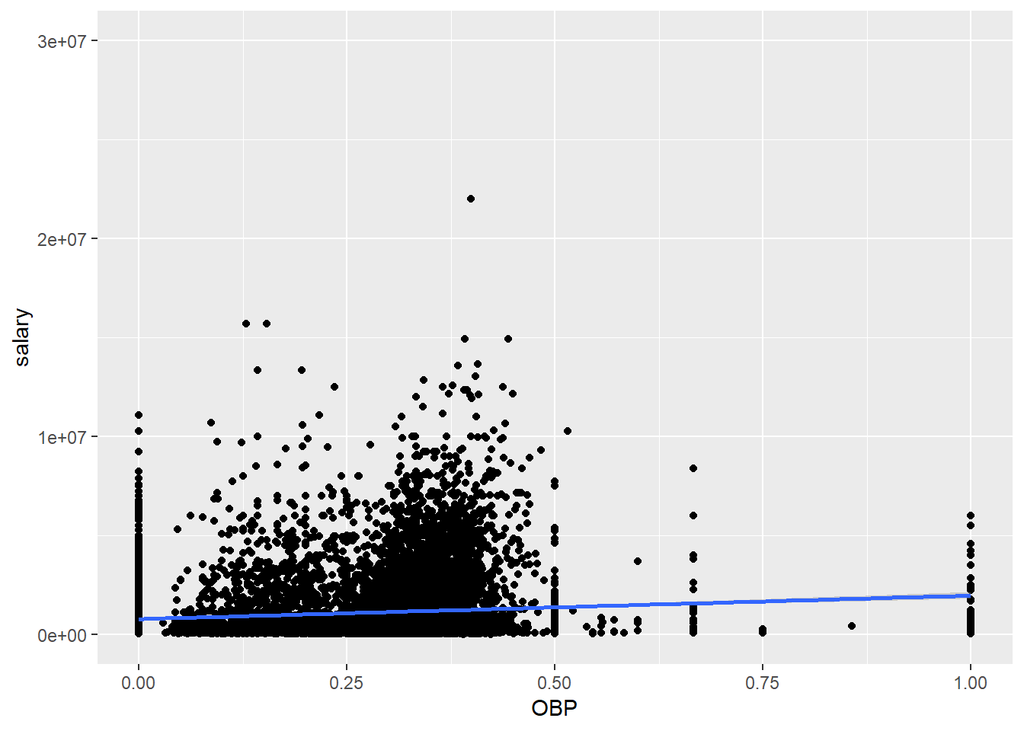

```r
combo.before2001 <- subset(combo,yearID <=2001)
ggplot(combo.before2001,aes(x=OBP,y=salary)) + geom_point() + geom_smooth(method='lm',formula=y~x) + scale_y_continuous(limits = c(0, 30000000))
```

This is interesting because there only seems to be a small correlation between OBP and salary. I expected such an important player statistic to be very closely correlated to how much a team would pay them. This could indicated that players before 2001 were chosen for less statistically driven reasons.

### Graph 2: OBP and salary after 2001

It might be interesting to see if after 2001 OBP is viewed as more valuable, since it wasn’t until after 2001 that choosing players based on statistics became more common.

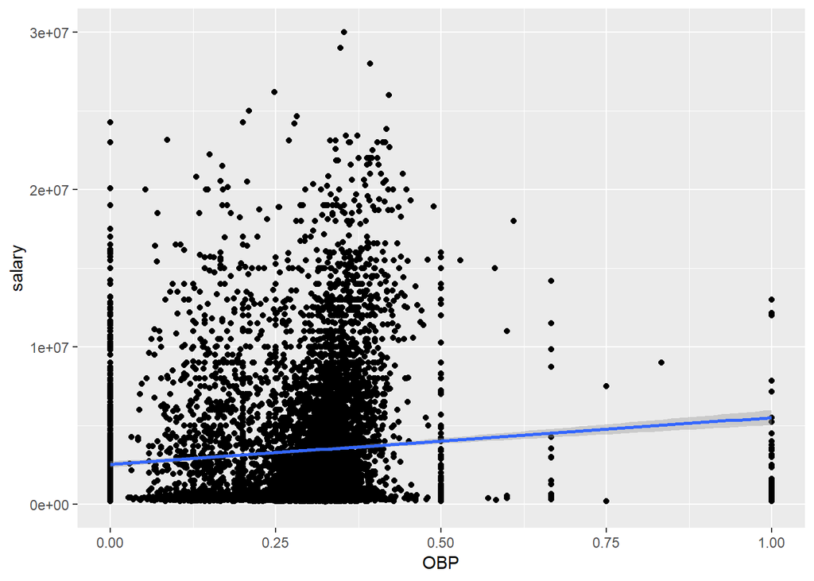

```r
combo.after2001 <- subset(combo,yearID >2001)
ggplot(combo.after2001,aes(x=OBP,y=salary)) + geom_point() + geom_smooth(method='lm',formula=y~x)+ scale_y_continuous(limits = c(0, 30000000))
```

The regression line seems both steeper and the whole line appears to have shifted up. The increased steepness implies that OBP and salary are more correlated after 2001, and the shifting up is probably due to just an overall increase in baseball player salaries. Although this would be a good place to further investigate. The increased correlation probably indicates that teams on average value OBP after 2001 higher than they teams did before 2001.

### Lets have a look at the lost players.

We need to keep in mind the player statistics for the lost players so that we can attempt to find better players for a smaller salary.

```r
lost_players <- subset(combo,playerID %in% c('damonjo01','giambja01','saenzol01'))

lost_players <- subset(lost_players, yearID == 2001, select = c('playerID','H','X2B','X3B','HR','OBP','SLG','BA','AB','salary'))

kable(lost_players, 'html', align = 'c') %>% kable_styling("striped")
```

|  | playerID | H | X2B | X3B | HR | OBP | SLG | BA | AB | salary |
| --- | --- | --- | --- | --- | --- | --- | --- | --- | --- | --- |
| 5141 | damonjo01 | 165 | 34 | 4 | 9 | 0.3235294 | 0.3633540 | 0.2562112 | 644 | 7100000 |
| 7878 | giambja01 | 178 | 47 | 2 | 38 | 0.4769001 | 0.6596154 | 0.3423077 | 520 | 4103333 |
| 20114 | saenzol01 | 67 | 21 | 1 | 9 | 0.2911765 | 0.3836066 | 0.2196721 | 305 | 290000 |

### Finding Replacement Players with 3 constraints.

1. Their combined salary can not exceed 15 million dollars
2. Their combined number of At Bats needs to be equal or greater than the lost players.
3. Their mean OBP has to be equal to or greater than the mean OBP of the lost players.

I’m going to look at players who would be good candidates. Since the salary cannot exceed 15 million, I will divide that by 3 (for each replacement). By doing this I will be filtering out some potentially good replacements, but **the following list will be chosen in a way that any 3 players can be selected from it and the constraints will be met.**

| playerID | H | X2B | X3B | HR | OBP | SLG | BA | AB | salary |
| --- | --- | --- | --- | --- | --- | --- | --- | --- | --- |
| giambja01 | 178 | 47 | 2 | 38 | 0.4769001 | 0.6596154 | 0.3423077 | 520 | 4103333 |
| heltoto01 | 197 | 54 | 2 | 49 | 0.4316547 | 0.6848382 | 0.3356048 | 587 | 4950000 |
| berkmla01 | 191 | 55 | 5 | 34 | 0.4302326 | 0.6204506 | 0.3310225 | 577 | 305000 |
| gonzalu01 | 198 | 36 | 7 | 57 | 0.4285714 | 0.6880131 | 0.3251232 | 609 | 4833333 |
| pujolal01 | 194 | 47 | 4 | 37 | 0.4029630 | 0.6101695 | 0.3288136 | 590 | 200000 |
| abreubo01 | 170 | 48 | 4 | 31 | 0.3934659 | 0.5425170 | 0.2891156 | 588 | 4983000 |
| nevinph01 | 167 | 31 | 0 | 41 | 0.3878205 | 0.5879121 | 0.3058608 | 546 | 1625000 |
| mientdo01 | 166 | 39 | 1 | 15 | 0.3865815 | 0.4640884 | 0.3057090 | 543 | 215000 |
| coninje01 | 163 | 23 | 2 | 14 | 0.3860233 | 0.4427481 | 0.3110687 | 524 | 3000000 |
| ordonma01 | 181 | 40 | 1 | 31 | 0.3815201 | 0.5328836 | 0.3052277 | 593 | 3750000 |
| pierrju01 | 202 | 26 | 11 | 2 | 0.3781764 | 0.4149109 | 0.3273906 | 617 | 215000 |
| nixontr01 | 150 | 31 | 4 | 27 | 0.3763955 | 0.5046729 | 0.2803738 | 535 | 390000 |
| grievbe01 | 143 | 30 | 2 | 11 | 0.3724570 | 0.3874539 | 0.2638376 | 542 | 2750000 |
| boonebr01 | 206 | 37 | 3 | 37 | 0.3722628 | 0.5778491 | 0.3306581 | 623 | 3250000 |
| stewash01 | 202 | 44 | 7 | 12 | 0.3710602 | 0.4625000 | 0.3156250 | 640 | 2183333 |
| caseyse01 | 165 | 40 | 0 | 13 | 0.3690476 | 0.4577861 | 0.3095685 | 533 | 3000000 |
| aurilri01 | 206 | 37 | 5 | 37 | 0.3688047 | 0.5723270 | 0.3238994 | 636 | 3250000 |
| glaustr01 | 147 | 38 | 2 | 41 | 0.3672316 | 0.5306122 | 0.2500000 | 588 | 1250000 |
| cirilje01 | 165 | 26 | 4 | 17 | 0.3641026 | 0.4734848 | 0.3125000 | 528 | 4850000 |

### Final Chosen Replacements

I selected the highlighted players above because they had especially low salaries, and were high up on the list which was ordered from highest OBP to lowest. But any combanation of players from this list would be good.

|  | playerID | H | X2B | X3B | HR | OBP | SLG | BA | AB | salary |
| --- | --- | --- | --- | --- | --- | --- | --- | --- | --- | --- |
| 1815 | berkmla01 | 191 | 55 | 5 | 34 | 0.4302326 | 0.6204506 | 0.3310225 | 577 | 305000 |
| 15162 | mientdo01 | 166 | 39 | 1 | 15 | 0.3865815 | 0.4640884 | 0.3057090 | 543 | 215000 |
| 18471 | pujolal01 | 194 | 47 | 4 | 37 | 0.4029630 | 0.6101695 | 0.3288136 | 590 | 200000 |

### Conclusion

| <sub><sub><sub>~</sub></sub></sub> | Lost Players | New Players | Difference |
| --- | --- | --- | --- |
| 1.Mean OBP | 0.364 | 0.407 | 0.043 increase |
| 2.Mean AB | 489.67 | 570 | 80.33 increase |
| 3.Mean SLG | 0.469 | 0.565 | 0.096 increase |
| 4..Sum of Salary | $11,493,333 | $720,000 | 10,773,333 decrease |

#### For almost 11 Million dollars less, we found 3 replacements with higher OBP’s and SLG’s.